# AllLife Bank Personal Loan Campaign - Logistic Regression & Decision Tree

#### Sequential Feature Selector

**Why we should do feature selection?**

- Reduces dimensionality.
- Discards deceptive features (Deceptive features appear to aid learning on the training set, but impair generalization).
- Speeds training/testing.

**How sequential feature selector works?**

- It starts with an empty model and adds in variables one by one.
- In each forward step, you add the one variable that gives the highest improvement to your model.

```python
# Sequential feature selector is present in mlxtend library
# !pip install mlxtend to install mlxtent library

from mlxtend.feature_selection import SequentialFeatureSelector as SFS

# to plot the performance with addition of each feature
from mlxtend.plotting import plot_sequential_feature_selection as plot_sfs
```

```python
# from sklearn.linear_model import LogisticRegression

# Fit the model on train
model = LogisticRegression(solver="newton-cg", n_jobs=-1, random_state=1, max_iter=100)
```

```python
# we will first build model with all varaible
sfs = SFS(
    model,
    k_features=11,
    forward=True,
    floating=False,
    scoring="f1",
    verbose=2,
    cv=3,
    n_jobs=-1,
)

sfs = sfs.fit(X_train, y_train)
```

```
[Parallel(n_jobs=-1)]: Using backend LokyBackend with 4 concurrent workers.
[Parallel(n_jobs=-1)]: Done  11 out of  11 | elapsed:    2.4s finished

[2021-08-07 09:06:38] Features: 1/11 -- score: 0.41343889085824576[Parallel(n_jobs=-1)]: Using backend LokyBackend with 4 concurrent workers.
[Parallel(n_jobs=-1)]: Done  10 out of  10 | elapsed:    0.7s finished

[2021-08-07 09:06:39] Features: 2/11 -- score: 0.5343065333269479[Parallel(n_jobs=-1)]: Using backend LokyBackend with 4 concurrent workers.
[Parallel(n_jobs=-1)]: Done   7 out of   9 | elapsed:    0.7s remaining:    0.2s
[Parallel(n_jobs=-1)]: Done   9 out of   9 | elapsed:    0.7s finished

[2021-08-07 09:06:39] Features: 3/11 -- score: 0.588710257767378[Parallel(n_jobs=-1)]: Using backend LokyBackend with 4 concurrent workers.
[Parallel(n_jobs=-1)]: Done   6 out of   8 | elapsed:    0.6s remaining:    0.2s
[Parallel(n_jobs=-1)]: Done   8 out of   8 | elapsed:    0.7s finished

[2021-08-07 09:06:40] Features: 4/11 -- score: 0.7247668393782384[Parallel(n_jobs=-1)]: Using backend LokyBackend with 4 concurrent workers.
[Parallel(n_jobs=-1)]: Done   4 out of   7 | elapsed:    0.4s remaining:    0.3s
[Parallel(n_jobs=-1)]: Done   7 out of   7 | elapsed:    0.6s finished

[2021-08-07 09:06:41] Features: 5/11 -- score: 0.754399957882545[Parallel(n_jobs=-1)]: Using backend LokyBackend with 4 concurrent workers.
[Parallel(n_jobs=-1)]: Done   3 out of   6 | elapsed:    0.3s remaining:    0.3s
[Parallel(n_jobs=-1)]: Done   6 out of   6 | elapsed:    0.5s finished

[2021-08-07 09:06:41] Features: 6/11 -- score: 0.7617423782550928[Parallel(n_jobs=-1)]: Using backend LokyBackend with 4 concurrent workers.
[Parallel(n_jobs=-1)]: Done   5 out of   5 | elapsed:    0.5s finished

[2021-08-07 09:06:42] Features: 7/11 -- score: 0.7673208908661803[Parallel(n_jobs=-1)]: Using backend LokyBackend with 4 concurrent workers.
[Parallel(n_jobs=-1)]: Done   4 out of   4 | elapsed:    0.4s finished

[2021-08-07 09:06:42] Features: 8/11 -- score: 0.7670844795354087[Parallel(n_jobs=-1)]: Using backend LokyBackend with 4 concurrent workers.
[Parallel(n_jobs=-1)]: Done   3 out of   3 | elapsed:    0.4s finished

[2021-08-07 09:06:42] Features: 9/11 -- score: 0.7653745980280119[Parallel(n_jobs=-1)]: Using backend LokyBackend with 4 concurrent workers.
[Parallel(n_jobs=-1)]: Done   2 out of   2 | elapsed:    0.3s finished

[2021-08-07 09:06:43] Features: 10/11 -- score: 0.7630169303900138[Parallel(n_jobs=-1)]: Using backend LokyBackend with 4 concurrent workers.
[Parallel(n_jobs=-1)]: Done   1 out of   1 | elapsed:    0.3s finished

[2021-08-07 09:06:43] Features: 11/11 -- score: 0.762289504092287
```

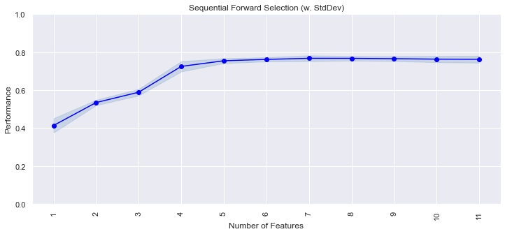

```python
fig1 = plot_sfs(sfs.get_metric_dict(), kind="std_dev", figsize=(12, 5))
plt.ylim([0.0, 1])
plt.title("Sequential Forward Selection (w. StdDev)")
plt.xticks(rotation=90)
plt.show()
```

**Observation**

```
[Parallel(n_jobs=-1)]: Using backend LokyBackend with 4 concurrent workers.
[Parallel(n_jobs=-1)]: Done  11 out of  11 | elapsed:    0.2s finished

[2021-08-07 09:06:43] Features: 1/6 -- score: 0.41343889085824576[Parallel(n_jobs=-1)]: Using backend LokyBackend with 4 concurrent workers.
[Parallel(n_jobs=-1)]: Done  10 out of  10 | elapsed:    0.7s finished

[2021-08-07 09:06:44] Features: 2/6 -- score: 0.5343065333269479[Parallel(n_jobs=-1)]: Using backend LokyBackend with 4 concurrent workers.
[Parallel(n_jobs=-1)]: Done   7 out of   9 | elapsed:    1.0s remaining:    0.3s
[Parallel(n_jobs=-1)]: Done   9 out of   9 | elapsed:    1.1s finished

[2021-08-07 09:06:45] Features: 3/6 -- score: 0.588710257767378[Parallel(n_jobs=-1)]: Using backend LokyBackend with 4 concurrent workers.
[Parallel(n_jobs=-1)]: Done   6 out of   8 | elapsed:    0.7s remaining:    0.2s
[Parallel(n_jobs=-1)]: Done   8 out of   8 | elapsed:    0.8s finished

[2021-08-07 09:06:46] Features: 4/6 -- score: 0.7247668393782384[Parallel(n_jobs=-1)]: Using backend LokyBackend with 4 concurrent workers.
[Parallel(n_jobs=-1)]: Done   4 out of   7 | elapsed:    0.5s remaining:    0.4s
[Parallel(n_jobs=-1)]: Done   7 out of   7 | elapsed:    0.6s finished

[2021-08-07 09:06:47] Features: 5/6 -- score: 0.754399957882545[Parallel(n_jobs=-1)]: Using backend LokyBackend with 4 concurrent workers.
[Parallel(n_jobs=-1)]: Done   3 out of   6 | elapsed:    0.4s remaining:    0.4s
[Parallel(n_jobs=-1)]: Done   6 out of   6 | elapsed:    0.6s finished

[2021-08-07 09:06:47] Features: 6/6 -- score: 0.7617423782550928
```

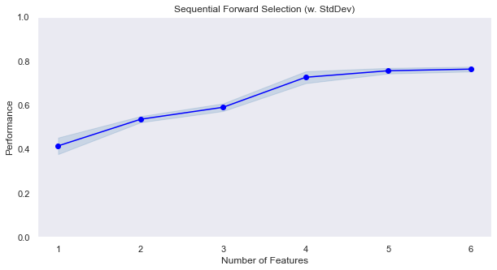

```python
sfs1 = SFS(
    model,
    k_features=6,
    forward=True,
    floating=False,
    scoring="f1",
    verbose=2,
    cv=3,
    n_jobs=-1,
)

sfs1 = sfs1.fit(X_train, y_train)

fig1 = plot_sfs(sfs1.get_metric_dict(), kind="std_dev", figsize=(10, 5))

plt.ylim([0.0, 1])
plt.title("Sequential Forward Selection (w. StdDev)")
plt.grid()
plt.show()
```

##### Finding which features are important?

```python
feat_cols = list(sfs1.k_feature_idx_)
print(feat_cols)
```

```
[1, 2, 6, 7, 9, 10]
```

```python
X_train.columns[feat_cols]
```

```
Index(['Income', 'Family', 'CD_Account', 'Online', 'Education_2',
       'Education_3'],
      dtype='object')
```

```python
X_train_final = X_train[X_train.columns[feat_cols]]

# Creating new x_test with the same variables that we selected for x_train
X_test_final = X_test[X_train_final.columns]
```

```python
# Fitting logistic regession model

logreg = LogisticRegression(
    solver="newton-cg", penalty="none", verbose=True, n_jobs=-1, random_state=0
)

# There are several optimizer, we are using optimizer called as 'newton-cg' with max_iter equal to 10000
# max_iter indicates number of iteration needed to converge

logreg.fit(X_train_final, y_train)
```

```
[Parallel(n_jobs=-1)]: Using backend LokyBackend with 4 concurrent workers.
[Parallel(n_jobs=-1)]: Done   1 out of   1 | elapsed:    0.1s finished
```

```
LogisticRegression(n_jobs=-1, penalty='none', random_state=0,
                   solver='newton-cg', verbose=True)
```

#### Let's Look at model performance

##### On training set

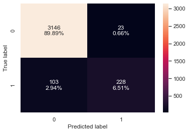

```python
confusion_matrix_with_threshold(logreg, X_train_final, y_train)
```

```python
log_reg_model_train_perf_SFS = model_performance_classification_with_threshold(
    logreg, X_train_final, y_train
)
print("Training performance:")
log_reg_model_train_perf_SFS
```

```
Training performance:
```

|  | Accuracy | Recall | Precision | F1 |
| --- | --- | --- | --- | --- |
| 0 | 0.964 | 0.688822 | 0.908367 | 0.783505 |

##### On test set

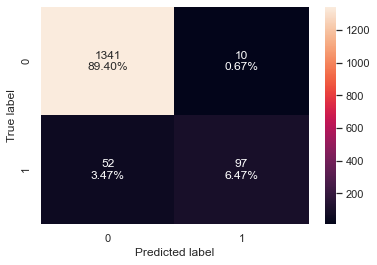

```python
confusion_matrix_with_threshold(logreg, X_test_final, y_test)
```

```python
log_reg_model_test_perf_SFS = model_performance_classification_with_threshold(
    logreg, X_test_final, y_test
)
print("Test set performance:")
log_reg_model_test_perf_SFS
```

```
Test set performance:
```

|  | Accuracy | Recall | Precision | F1 |
| --- | --- | --- | --- | --- |
| 0 | 0.958667 | 0.651007 | 0.906542 | 0.757813 |

**Observation**

- Model is giving a generalized performance on training and test set.
- With a fewer number of features, the model performance is comparable to the initial logistic regression model.

#### Model Performance Summary

```python
models_train_comp_df = pd.concat(
    [
        log_reg_model_train_perf.T,
        log_reg_model_train_perf_threshold_auc_roc.T,
        log_reg_model_train_perf_threshold_curve.T,
        log_reg_model_train_perf_SFS.T,
    ],
    axis=1,
)
models_train_comp_df.columns = [
    "Logistic Regression sklearn",
    "Logistic Regression-0.10 Threshold",
    "Logistic Regression-0.35 Threshold",
    "Logistic Regression - SFS",
]


# testing performance comparison

models_test_comp_df = pd.concat(
    [
        log_reg_model_test_perf.T,
        log_reg_model_test_perf_threshold_auc_roc.T,
        log_reg_model_test_perf_threshold_curve.T,
        log_reg_model_test_perf_SFS.T,
    ],
    axis=1,
)
models_test_comp_df.columns = [
    "Logistic Regression sklearn",
    "Logistic Regression-0.10 Threshold",
    "Logistic Regression-0.35 Threshold",
    "Logistic Regression - SFS",
]
```

```python
print("Training performance comparison:")
models_train_comp_df
```

```
Training performance comparison:
```

|  | Logistic Regression sklearn | Logistic Regression-0.10 Threshold | Logistic Regression-0.35 Threshold | Logistic Regression - SFS |
| --- | --- | --- | --- | --- |
| Accuracy | 0.961143 | 0.906857 | 0.959143 | 0.964000 |
| Recall | 0.682779 | 0.906344 | 0.776435 | 0.688822 |
| Precision | 0.879377 | 0.504202 | 0.788344 | 0.908367 |
| F1 | 0.768707 | 0.647948 | 0.782344 | 0.783505 |

```python
print("Test set performance comparison:")
models_test_comp_df
```

```
Test set performance comparison:
```

|  | Logistic Regression sklearn | Logistic Regression-0.10 Threshold | Logistic Regression-0.35 Threshold | Logistic Regression - SFS |
| --- | --- | --- | --- | --- |
| Accuracy | 0.956667 | 0.906667 | 0.956667 | 0.958667 |
| Recall | 0.644295 | 0.885906 | 0.738255 | 0.651007 |
| Precision | 0.888889 | 0.517647 | 0.808824 | 0.906542 |
| F1 | 0.747082 | 0.653465 | 0.771930 | 0.757813 |

**Observation**

### Insight based on Logistic Regression

- We have build the predictive model `Logistic Regression-0.10 Threshold` that can be used by Bank to determine who can take loan. This model has Accuracy of 90% and 88.5% recall
- We also found that feature `Income`, `Family`, `CD_Account`, `Education` plays positive role in determining whether customer will take loan or not.

### Decision Tree

#### Utility methods for classification

```python
##  Function to calculate recall score
def get_recall_score(model, predictors, target):
    """
    model: classifier
    predictors: independent variables
    target: dependent variable

    """
    prediction = model.predict(predictors)

    acc = accuracy_score(target, prediction)  # to compute Accuracy
    recall = recall_score(target, prediction)  # to compute Recall
    precision = precision_score(target, prediction)  # to compute Precision
    f1 = f1_score(target, prediction)  # to compute F1-score

    # creating a dataframe of metrics
    df_perf = pd.DataFrame(
        {
            "Accuracy": acc,
            "Recall": recall,
            "Precision": precision,
            "F1": f1,
        },
        index=[0],
    )

    return df_perf


def confusion_matrix_dt(model, predictors, target):
    """
    To plot the confusion_matrix with percentages

    model: classifier
    predictors: independent variables
    target: dependent variable
    """
    y_pred = model.predict(predictors)
    cm = confusion_matrix(target, y_pred)
    labels = np.asarray(
        [
            ["{0:0.0f}".format(item) + "\n{0:.2%}".format(item / cm.flatten().sum())]
            for item in cm.flatten()
        ]
    ).reshape(2, 2)

    plt.figure(figsize=(6, 4))
    sns.heatmap(cm, annot=labels, fmt="")
    plt.ylabel("True label")
    plt.xlabel("Predicted label")

def drawDecisionTree(model,feature_names):
    out = tree.plot_tree(
        model,
        feature_names=feature_names,
        filled=True,
        fontsize=9,
        node_ids=False,
        class_names=None,
    )
    # below code will add arrows to the decision tree split if they are missing
    for o in out:
        arrow = o.arrow_patch
        if arrow is not None:
            arrow.set_edgecolor("black")
            arrow.set_linewidth(1)
```

#### Build Decision Tree Model

- We will build our model using the DecisionTreeClassifier function. Using default 'gini' criteria to split.
- If the frequency of class 1 is 10% and the frequency of class 2 is 90%, then class B will become the dominant class and the decision tree will become biased toward the dominant classes.
- In this case, we can pass a dictionary {0:0.20,1:0.80} to the model to specify the weight of each class and the decision tree will give more weightage to class 1.
- class_weight is a hyperparameter for the decision tree classifier.

```python
model = DecisionTreeClassifier(
    criterion="gini", class_weight={0: 0.20, 1: 0.80}, random_state=1
)
```

```python
model.fit(X_train, y_train)
```

```
DecisionTreeClassifier(class_weight={0: 0.2, 1: 0.8}, random_state=1)
```

##### Checking model performance on training set

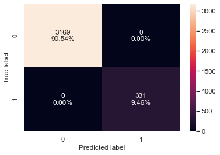

```python
confusion_matrix_dt(model, X_train, y_train)
```

```python
decision_tree_perf_train = get_recall_score(model, X_train, y_train)
print("Recall Score:", decision_tree_perf_train)
```

```
Recall Score:    Accuracy  Recall  Precision   F1
0       1.0     1.0        1.0  1.0
```

**Observation**

- Model is able to perfectly classify all the data points on the training set.
- 0 errors on the training set, each sample has been classified correctly.

##### Checking model performance on test set

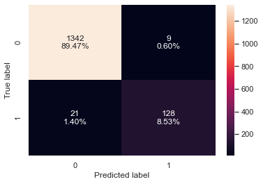

```python
confusion_matrix_dt(model, X_test, y_test)
```

```python
decision_tree_perf_test = get_recall_score(model, X_test, y_test)
print("Recall Score:", decision_tree_perf_test)
```

```
Recall Score:    Accuracy   Recall  Precision        F1
0      0.98  0.85906   0.934307  0.895105
```

**Observation**

- There is a significant disparity in performance of model on training set and test set, which suggests that the model is overfiiting.

#### Visualizing the Decision Tree

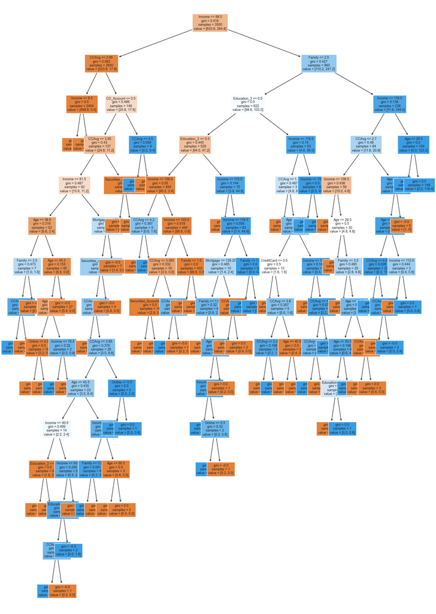

```python
## creating a list of column names
feature_names = X_train.columns.to_list()

plt.figure(figsize=(20, 30))
drawDecisionTree(model,feature_names)
plt.show()
```

```python
print(tree.export_text(model, feature_names=feature_names, show_weights=True))
```

```
|--- Income <= 98.50
|   |--- CCAvg <= 2.95
|   |   |--- Income <= 8.50
|   |   |   |--- weights: [3.40, 0.00] class: 0
|   |   |--- Income >  8.50
|   |   |   |--- weights: [495.40, 0.00] class: 0
|   |--- CCAvg >  2.95
|   |   |--- CD_Account <= 0.50
|   |   |   |--- CCAvg <= 3.95
|   |   |   |   |--- Income <= 81.50
|   |   |   |   |   |--- Age <= 36.50
|   |   |   |   |   |   |--- Family <= 3.50
|   |   |   |   |   |   |   |--- CCAvg <= 3.50
|   |   |   |   |   |   |   |   |--- weights: [0.00, 1.60] class: 1
|   |   |   |   |   |   |   |--- CCAvg >  3.50
|   |   |   |   |   |   |   |   |--- weights: [0.20, 0.00] class: 0
|   |   |   |   |   |   |--- Family >  3.50
|   |   |   |   |   |   |   |--- weights: [0.80, 0.00] class: 0
|   |   |   |   |   |--- Age >  36.50
|   |   |   |   |   |   |--- Age <= 45.50
|   |   |   |   |   |   |   |--- Age <= 43.50
|   |   |   |   |   |   |   |   |--- Online <= 0.50
|   |   |   |   |   |   |   |   |   |--- weights: [1.40, 0.00] class: 0
|   |   |   |   |   |   |   |   |--- Online >  0.50
|   |   |   |   |   |   |   |   |   |--- weights: [1.80, 0.00] class: 0
|   |   |   |   |   |   |   |--- Age >  43.50
|   |   |   |   |   |   |   |   |--- Income <= 76.50
|   |   |   |   |   |   |   |   |   |--- weights: [0.00, 0.80] class: 1
|   |   |   |   |   |   |   |   |--- Income >  76.50
|   |   |   |   |   |   |   |   |   |--- weights: [0.20, 0.00] class: 0
|   |   |   |   |   |   |--- Age >  45.50
|   |   |   |   |   |   |   |--- weights: [5.40, 0.00] class: 0
|   |   |   |   |--- Income >  81.50
|   |   |   |   |   |--- Mortgage <= 152.00
|   |   |   |   |   |   |--- Securities_Account <= 0.50
|   |   |   |   |   |   |   |--- CCAvg <= 3.05
|   |   |   |   |   |   |   |   |--- weights: [0.60, 0.00] class: 0
|   |   |   |   |   |   |   |--- CCAvg >  3.05
|   |   |   |   |   |   |   |   |--- CCAvg <= 3.85
|   |   |   |   |   |   |   |   |   |--- Age <= 45.50
```

[output cut: 150 more lines]

```
|   |   |   |   |   |   |   |   |--- weights: [0.20, 0.00] class: 0
|   |   |   |   |   |   |   |--- CCAvg >  4.95
|   |   |   |   |   |   |   |   |--- weights: [0.00, 2.40] class: 1
|   |   |   |   |   |--- Age >  57.50
|   |   |   |   |   |   |--- Income <= 112.00
|   |   |   |   |   |   |   |--- weights: [0.40, 0.00] class: 0
|   |   |   |   |   |   |--- Income >  112.00
|   |   |   |   |   |   |   |--- weights: [0.00, 0.80] class: 1
|   |   |   |   |--- Age >  59.50
|   |   |   |   |   |--- weights: [1.00, 0.00] class: 0
|   |   |--- Income >  116.50
|   |   |   |--- Age <= 26.50
|   |   |   |   |--- weights: [0.00, 4.80] class: 1
|   |   |   |--- Age >  26.50
|   |   |   |   |--- weights: [0.00, 118.40] class: 1
```

**Observation**

- The tree above is complex and difficult to interpret. It can be simplified

```python
# importance of features in the tree building ( The importance of a feature is computed as the
# (normalized) total reduction of the criterion brought by that feature. It is also known as the Gini importance )

print(
    pd.DataFrame(
        model.feature_importances_, columns=["Imp"], index=X_train.columns
    ).sort_values(by="Imp", ascending=False)
)
```

```
                         Imp
Income              0.569035
Education_2         0.136969
Family              0.088408
Education_3         0.080947
CCAvg               0.078971
Age                 0.022790
CD_Account          0.012873
Mortgage            0.005176
Securities_Account  0.002027
CreditCard          0.001947
Online              0.000857
```

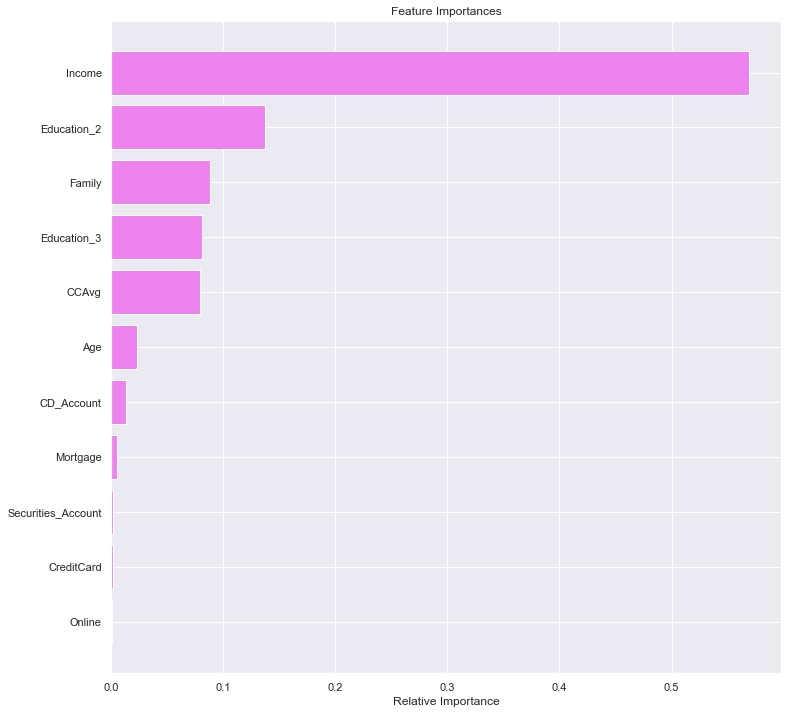

```python
importances = model.feature_importances_
indices = np.argsort(importances)

plt.figure(figsize=(12, 12))
plt.title("Feature Importances")
plt.barh(range(len(indices)), importances[indices], color="violet", align="center")
plt.yticks(range(len(indices)), [feature_names[i] for i in indices])
plt.xlabel("Relative Importance")
plt.show()
```

**Observation**

#### Reducing over fitting

##### Using GridSearch for Hyperparameter tuning of our tree model¶

```python
# Choose the type of classifier.
estimator = DecisionTreeClassifier(random_state=1, class_weight={0: 0.20, 1: 0.80})

# Grid of parameters to choose from
parameters = {
    "max_depth": [5, 10, 15, None],
    "criterion": ["entropy", "gini"],
    "splitter": ["best", "random"],
    "min_impurity_decrease": [0.00001, 0.0001, 0.01],
}

# Type of scoring used to compare parameter combinations
scorer = make_scorer(recall_score)

# Run the grid search
grid_obj = GridSearchCV(estimator, parameters, scoring=scorer, cv=5)
grid_obj = grid_obj.fit(X_train, y_train)

# Set the clf to the best combination of parameters
estimator = grid_obj.best_estimator_

# Fit the best algorithm to the data.
estimator.fit(X_train, y_train)
```

```
DecisionTreeClassifier(class_weight={0: 0.2, 1: 0.8}, max_depth=5,
                       min_impurity_decrease=0.01, random_state=1,
                       splitter='random')
```

##### Checking performance on training set

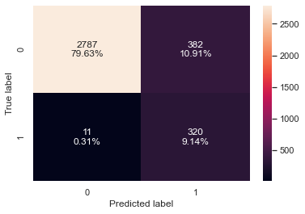

```python
confusion_matrix_dt(estimator, X_train, y_train)
```

```python
decision_tree_tune_perf_train = get_recall_score(estimator, X_train, y_train)
print("Recall Score:", decision_tree_tune_perf_train)
```

```
Recall Score:    Accuracy    Recall  Precision        F1
0  0.887714  0.966767    0.45584  0.619555
```

##### Checking performance on test set

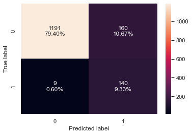

```python
confusion_matrix_dt(estimator, X_test, y_test)
```

```python
decision_tree_tune_perf_test = get_recall_score(estimator, X_test, y_test)
print("Recall Score:", decision_tree_tune_perf_test)
```

```
Recall Score:    Accuracy    Recall  Precision        F1
0  0.887333  0.939597   0.466667  0.623608
```

##### Visualizing the Decision Tree

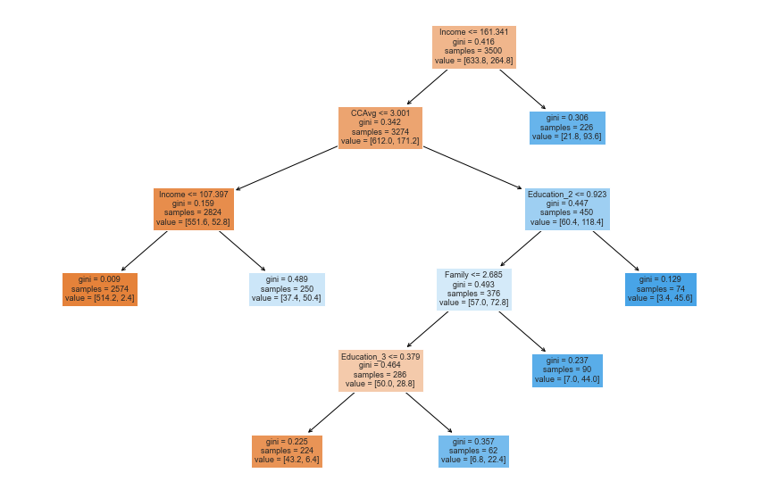

```python
plt.figure(figsize=(15, 10))
drawDecisionTree(estimator,feature_names)
plt.show()
```

```python
print(tree.export_text(estimator, feature_names=feature_names, show_weights=True))
```

```
|--- Income <= 161.34
|   |--- CCAvg <= 3.00
|   |   |--- Income <= 107.40
|   |   |   |--- weights: [514.20, 2.40] class: 0
|   |   |--- Income >  107.40
|   |   |   |--- weights: [37.40, 50.40] class: 1
|   |--- CCAvg >  3.00
|   |   |--- Education_2 <= 0.92
|   |   |   |--- Family <= 2.68
|   |   |   |   |--- Education_3 <= 0.38
|   |   |   |   |   |--- weights: [43.20, 6.40] class: 0
|   |   |   |   |--- Education_3 >  0.38
|   |   |   |   |   |--- weights: [6.80, 22.40] class: 1
|   |   |   |--- Family >  2.68
|   |   |   |   |--- weights: [7.00, 44.00] class: 1
|   |   |--- Education_2 >  0.92
|   |   |   |--- weights: [3.40, 45.60] class: 1
|--- Income >  161.34
|   |--- weights: [21.80, 93.60] class: 1
```

```python
# importance of features in the tree building ( The importance of a feature is computed as the
# (normalized) total reduction of the 'criterion' brought by that feature. It is also known as the Gini importance )

print(
    pd.DataFrame(
        estimator.feature_importances_, columns=["Imp"], index=X_train.columns
    ).sort_values(by="Imp", ascending=False)
)

# Here we will see that importance of features has increased
```

```
                         Imp
Income              0.476218
CCAvg               0.364063
Family              0.061132
Education_3         0.059755
Education_2         0.038832
Age                 0.000000
Mortgage            0.000000
Securities_Account  0.000000
CD_Account          0.000000
Online              0.000000
CreditCard          0.000000
```

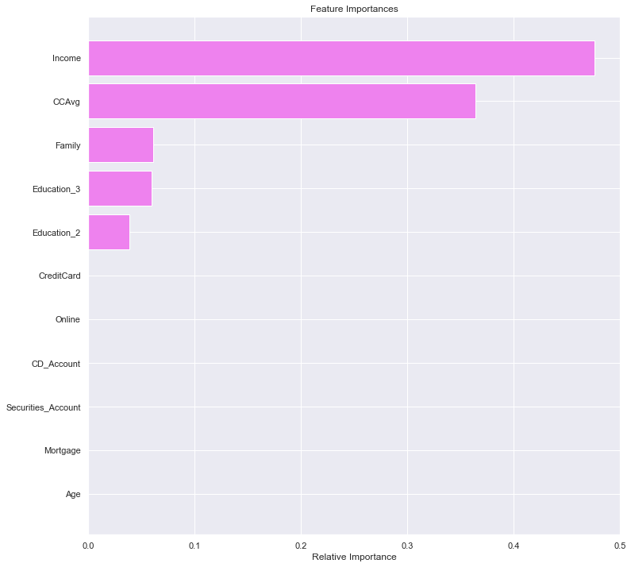

```python
importances = estimator.feature_importances_
indices = np.argsort(importances)

plt.figure(figsize=(12, 12))
plt.title("Feature Importances")
plt.barh(range(len(indices)), importances[indices], color="violet", align="center")
plt.yticks(range(len(indices)), [feature_names[i] for i in indices])
plt.xlabel("Relative Importance")
plt.show()
```

**Observation** **Observation**

#### Cost Complexity Pruning

```python
clf = DecisionTreeClassifier(random_state=1, class_weight={0: 0.15, 1: 0.85})
path = clf.cost_complexity_pruning_path(X_train, y_train)
ccp_alphas, impurities = path.ccp_alphas, path.impurities
```

```python
pd.DataFrame(path)
```

|  | ccp_alphas | impurities |
| --- | --- | --- |
| 0 | 0.000000e+00 | -9.909529e-15 |
| 1 | 7.482671e-19 | -9.908781e-15 |
| 2 | 7.482671e-19 | -9.908033e-15 |
| 3 | 7.482671e-19 | -9.907284e-15 |
| 4 | 7.482671e-19 | -9.906536e-15 |
| 5 | 9.976895e-19 | -9.905538e-15 |
| 6 | 1.760629e-18 | -9.903778e-15 |
| 7 | 1.760629e-18 | -9.902017e-15 |
| 8 | 1.892676e-18 | -9.900124e-15 |
| 9 | 2.332833e-18 | -9.897792e-15 |
| 10 | 4.291532e-18 | -9.893500e-15 |
| 11 | 4.665666e-18 | -9.888834e-15 |
| 12 | 5.854090e-18 | -9.882980e-15 |
| 13 | 1.143528e-16 | -9.768627e-15 |
| 14 | 1.872164e-04 | 3.744328e-04 |
| 15 | 1.872164e-04 | 7.488657e-04 |
| 16 | 1.925655e-04 | 1.133997e-03 |
| 17 | 1.957616e-04 | 1.525520e-03 |
| 18 | 3.182679e-04 | 2.162056e-03 |
| 19 | 3.369896e-04 | 2.499045e-03 |
| 20 | 3.369896e-04 | 2.836035e-03 |
| 21 | 3.637348e-04 | 3.199769e-03 |
| 22 | 3.643130e-04 | 3.564083e-03 |
| 23 | 3.643130e-04 | 3.928396e-03 |
| 24 | 3.829427e-04 | 4.311338e-03 |
| 25 | 3.879017e-04 | 4.699240e-03 |
| 26 | 5.464696e-04 | 5.792179e-03 |
| 27 | 5.761229e-04 | 6.368302e-03 |
| 28 | 5.907779e-04 | 8.731414e-03 |
| 29 | 6.352125e-04 | 9.366626e-03 |
| 30 | 6.925559e-04 | 1.005918e-02 |
| 31 | 7.793952e-04 | 1.161797e-02 |
| 32 | 8.174649e-04 | 1.570530e-02 |
| 33 | 8.266422e-04 | 1.735858e-02 |
| 34 | 8.521714e-04 | 1.906292e-02 |
| 35 | 9.095010e-04 | 1.997242e-02 |
| 36 | 9.404360e-04 | 2.091286e-02 |
| 37 | 9.407728e-04 | 2.279441e-02 |
| 38 | 1.011155e-03 | 2.380556e-02 |
| 39 | 1.399934e-03 | 2.520550e-02 |
| 40 | 1.566857e-03 | 2.677235e-02 |
| 41 | 1.638043e-03 | 2.841040e-02 |
| 42 | 1.697429e-03 | 3.010782e-02 |
| 43 | 1.819971e-03 | 3.192780e-02 |
| 44 | 2.685352e-03 | 3.729850e-02 |
| 45 | 2.742431e-03 | 4.004093e-02 |
| 46 | 2.758322e-03 | 4.279925e-02 |
| 47 | 3.335999e-03 | 4.613525e-02 |
| 48 | 3.527226e-03 | 4.966248e-02 |
| 49 | 4.169566e-03 | 5.383204e-02 |
| 50 | 4.391862e-03 | 5.822390e-02 |
| 51 | 5.138280e-03 | 6.336218e-02 |
| 52 | 5.262465e-03 | 6.862465e-02 |
| 53 | 2.253222e-02 | 9.115687e-02 |
| 54 | 4.072766e-02 | 2.133399e-01 |
| 55 | 2.537957e-01 | 4.671356e-01 |

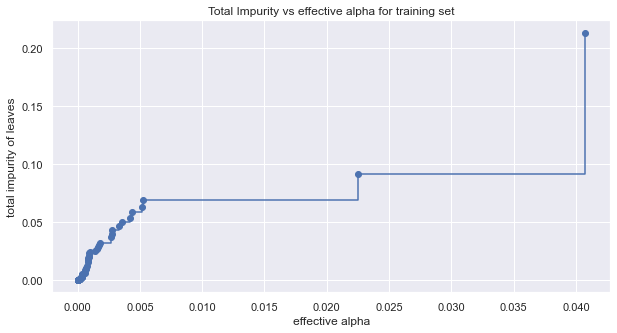

```python
fig, ax = plt.subplots(figsize=(10, 5))
ax.plot(ccp_alphas[:-1], impurities[:-1], marker="o", drawstyle="steps-post")
ax.set_xlabel("effective alpha")
ax.set_ylabel("total impurity of leaves")
ax.set_title("Total Impurity vs effective alpha for training set")
plt.show()
```

Next, we train a decision tree using the effective alphas. The last value in ccp_alphas is the alpha value that prunes the whole tree, leaving the tree, clfs[-1], with one node.

```python
clfs = []
for ccp_alpha in ccp_alphas:
    clf = DecisionTreeClassifier(
        random_state=1, ccp_alpha=ccp_alpha, class_weight={0: 0.15, 1: 0.85}
    )
    clf.fit(X_train, y_train)
    clfs.append(clf)
print(
    "Number of nodes in the last tree is: {} with ccp_alpha: {}".format(
        clfs[-1].tree_.node_count, ccp_alphas[-1]
    )
)
```

```
Number of nodes in the last tree is: 1 with ccp_alpha: 0.2537957148948092
```

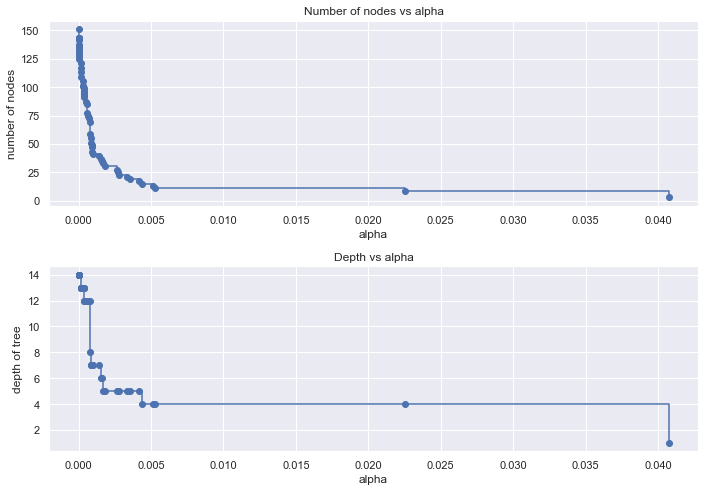

```python
clfs = clfs[:-1]
ccp_alphas = ccp_alphas[:-1]

node_counts = [clf.tree_.node_count for clf in clfs]
depth = [clf.tree_.max_depth for clf in clfs]
fig, ax = plt.subplots(2, 1, figsize=(10, 7))
ax[0].plot(ccp_alphas, node_counts, marker="o", drawstyle="steps-post")
ax[0].set_xlabel("alpha")
ax[0].set_ylabel("number of nodes")
ax[0].set_title("Number of nodes vs alpha")
ax[1].plot(ccp_alphas, depth, marker="o", drawstyle="steps-post")
ax[1].set_xlabel("alpha")
ax[1].set_ylabel("depth of tree")
ax[1].set_title("Depth vs alpha")
fig.tight_layout()
```

```python
recall_train = []
for clf in clfs:
    pred_train = clf.predict(X_train)
    values_train = recall_score(y_train, pred_train)
    recall_train.append(values_train)
```

```python
recall_test = []
for clf in clfs:
    pred_test = clf.predict(X_test)
    values_test = recall_score(y_test, pred_test)
    recall_test.append(values_test)
```

```python
train_scores = [clf.score(X_train, y_train) for clf in clfs]
test_scores = [clf.score(X_test, y_test) for clf in clfs]
```

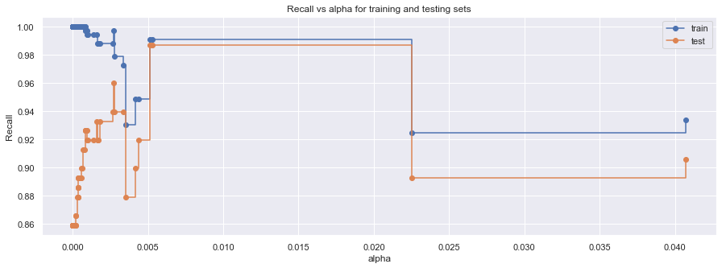

```python
fig, ax = plt.subplots(figsize=(15, 5))
ax.set_xlabel("alpha")
ax.set_ylabel("Recall")
ax.set_title("Recall vs alpha for training and testing sets")
ax.plot(
    ccp_alphas, recall_train, marker="o", label="train", drawstyle="steps-post",
)
ax.plot(ccp_alphas, recall_test, marker="o", label="test", drawstyle="steps-post")
ax.legend()
plt.show()
```

```python
# creating the model where we get highest train and test recall
index_best_model = np.argmax(recall_test)
best_model = clfs[index_best_model]
print(best_model)
```

```
DecisionTreeClassifier(ccp_alpha=0.005138280016554083,
                       class_weight={0: 0.15, 1: 0.85}, random_state=1)
```

```python
best_model.fit(X_train, y_train)
```

```
DecisionTreeClassifier(ccp_alpha=0.005138280016554083,
                       class_weight={0: 0.15, 1: 0.85}, random_state=1)
```

##### Checking performance on training set

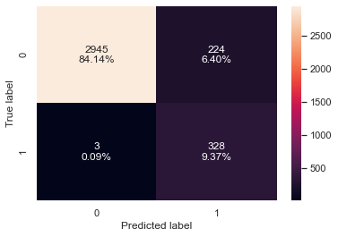

```python
confusion_matrix_dt(best_model, X_train, y_train)
```

```python
print("Recall Score:", get_recall_score(best_model, X_train, y_train))
```

```
Recall Score:    Accuracy    Recall  Precision        F1
0  0.935143  0.990937   0.594203  0.742922
```

##### Checking performance on test set

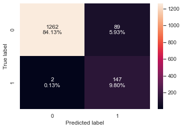

```python
confusion_matrix_dt(best_model, X_test, y_test)
```

```python
print("Recall Score:", get_recall_score(best_model, X_test, y_test))
```

```
Recall Score:    Accuracy    Recall  Precision        F1
0  0.939333  0.986577   0.622881  0.763636
```

##### Visualizing the Decision Tree

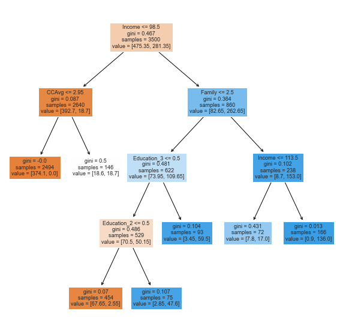

```python
plt.figure(figsize=(10, 10))
drawDecisionTree(best_model,feature_names)
plt.show()
```

This model might be giving the highest recall but a buisness would not be able to use it to actually target the potential customers

##### Creating model with 0.005 ccp_alpha

```python
best_model2 = DecisionTreeClassifier(
    ccp_alpha=0.005, class_weight={0: 0.15, 1: 0.85}, random_state=1
)
best_model2.fit(X_train, y_train)
```

```
DecisionTreeClassifier(ccp_alpha=0.005, class_weight={0: 0.15, 1: 0.85},
                       random_state=1)
```

##### Checking performance on the training set

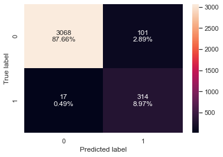

```python
confusion_matrix_dt(best_model2, X_train, y_train)
```

```python
decision_tree_postpruned_perf_train = get_recall_score(best_model2, X_train, y_train)
print("Recall Score:", decision_tree_postpruned_perf_train)
```

```
Recall Score:    Accuracy   Recall  Precision        F1
0  0.966286  0.94864   0.756627  0.841823
```

##### Checking performance on the test set

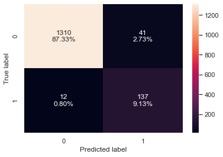

```python
confusion_matrix_dt(best_model2, X_test, y_test)
```

```python
decision_tree_postpruned_perf_test = get_recall_score(best_model2, X_test, y_test)
print("Recall Score:", decision_tree_postpruned_perf_test)
```

```
Recall Score:    Accuracy    Recall  Precision       F1
0  0.964667  0.919463   0.769663  0.83792
```

**Observation**

- The results have improved from the initial model.
- The performance is comparable to the hyperparameter tuned model.
- The model is giving a generalized performance on training and test set

##### Visualizing the Decision Tree

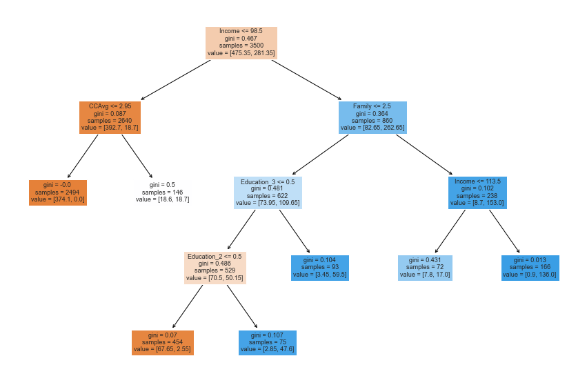

```python
plt.figure(figsize=(15, 10))
drawDecisionTree(best_model,feature_names)
plt.show()
```

```python
# Text report showing the rules of a decision tree -
print(tree.export_text(best_model2, feature_names=feature_names, show_weights=True))
```

```
|--- Income <= 98.50
|   |--- CCAvg <= 2.95
|   |   |--- weights: [374.10, 0.00] class: 0
|   |--- CCAvg >  2.95
|   |   |--- CD_Account <= 0.50
|   |   |   |--- weights: [18.45, 11.90] class: 0
|   |   |--- CD_Account >  0.50
|   |   |   |--- weights: [0.15, 6.80] class: 1
|--- Income >  98.50
|   |--- Family <= 2.50
|   |   |--- Education_3 <= 0.50
|   |   |   |--- Education_2 <= 0.50
|   |   |   |   |--- weights: [67.65, 2.55] class: 0
|   |   |   |--- Education_2 >  0.50
|   |   |   |   |--- weights: [2.85, 47.60] class: 1
|   |   |--- Education_3 >  0.50
|   |   |   |--- weights: [3.45, 59.50] class: 1
|   |--- Family >  2.50
|   |   |--- Income <= 113.50
|   |   |   |--- weights: [7.80, 17.00] class: 1
|   |   |--- Income >  113.50
|   |   |   |--- weights: [0.90, 136.00] class: 1
```

```python
# importance of features in the tree building ( The importance of a feature is computed as the
# (normalized) total reduction of the 'criterion' brought by that feature. It is also known as the Gini importance )

print(
    pd.DataFrame(
        best_model2.feature_importances_, columns=["Imp"], index=X_train.columns
    ).sort_values(by="Imp", ascending=False)
)
```

```
                         Imp
Income              0.633531
Education_2         0.156149
Education_3         0.074973
Family              0.067678
CCAvg               0.055103
CD_Account          0.012566
Age                 0.000000
Mortgage            0.000000
Securities_Account  0.000000
Online              0.000000
CreditCard          0.000000
```

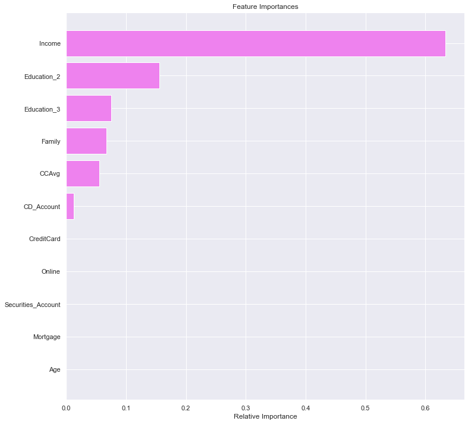

```python
importances = best_model2.feature_importances_
indices = np.argsort(importances)

plt.figure(figsize=(12, 12))
plt.title("Feature Importances")
plt.barh(range(len(indices)), importances[indices], color="violet", align="center")
plt.yticks(range(len(indices)), [feature_names[i] for i in indices])
plt.xlabel("Relative Importance")
plt.show()
```

**Observation**

- Most important feature is income and education (level 2 - Graduate)
- Customers with income above 98.50 and Family member above 2 is most likly to take loan
- Advance Degree Customers with income above 98.50 and Family member around 2 is most likly to take loan
- Customers with income less than equal to 98.50 and CCAvg > 2.95 and have CD_Account likly to take loan
- Customers with income less than equal to 98.50 and CCAvg <=2.95 is very less likly to take loan

#### Comparing all the decision tree models

```python
# training performance comparison

models_train_comp_df = pd.concat(
    [
        decision_tree_perf_train.T,
        decision_tree_tune_perf_train.T,
        decision_tree_postpruned_perf_train.T,
    ],axis=1

)


models_train_comp_df.columns = [
    "Initial decision tree model",
    "Decision treee with hyperparameter tuning",
    "Decision tree with post-pruning",
]


# testing performance comparison

models_test_comp_df = pd.concat(
    [
        decision_tree_perf_test.T,
        decision_tree_tune_perf_test.T,
        decision_tree_postpruned_perf_test.T,
    ],axis=1
)

models_test_comp_df.columns = [
    "Initial decision tree model",
    "Decision treee with hyperparameter tuning",
    "Decision tree with post-pruning",
]
```

```python
print("Training performance comparison:")
models_train_comp_df
```

```
Training performance comparison:
```

|  | Initial decision tree model | Decision treee with hyperparameter tuning | Decision tree with post-pruning |
| --- | --- | --- | --- |
| Accuracy | 1.0 | 0.887714 | 0.966286 |
| Recall | 1.0 | 0.966767 | 0.948640 |
| Precision | 1.0 | 0.455840 | 0.756627 |
| F1 | 1.0 | 0.619555 | 0.841823 |

```python
print("Test performance comparison:")
models_test_comp_df
```

```
Test performance comparison:
```

|  | Initial decision tree model | Decision treee with hyperparameter tuning | Decision tree with post-pruning |
| --- | --- | --- | --- |
| Accuracy | 0.980000 | 0.887333 | 0.964667 |
| Recall | 0.859060 | 0.939597 | 0.919463 |
| Precision | 0.934307 | 0.466667 | 0.769663 |
| F1 | 0.895105 | 0.623608 | 0.837920 |

**Observation**

### incorrectly predicted data Analysis

```python
incorrect_class_df = X_test.copy()
```

```python
incorrect_class_df['Actual']=y_test
y_predicate = best_model2.predict(X_test)
incorrect_class_df['Predicted'] = y_predicate
```

```python
pd.crosstab(incorrect_class_df['Predicted'],incorrect_class_df['Actual'],margins=True)
```

| Actual Predicted | 0 | 1 | All |
| --- | --- | --- | --- |
| 0 | 1310 | 12 | 1322 |
| 1 | 41 | 137 | 178 |
| All | 1351 | 149 | 1500 |

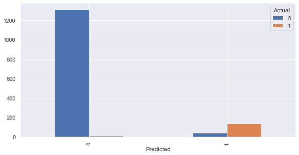

```python
pd.crosstab(incorrect_class_df['Predicted'],incorrect_class_df['Actual']).plot(kind='bar',figsize=(10,5))
```

```python
# FlaseNegative - Rows in which - it is predicated that customer will not take loan but actually taken
FalseNegativeRows = incorrect_class_df[(incorrect_class_df['Actual'] == 1) & (incorrect_class_df['Predicted'] == 0)]
falseNegativeDf=incorrect_class_df[incorrect_class_df.index.isin(FalseNegativeRows.index.values)].copy()
```

```python
print ("Number of Rows for False Negative: "+str(len(falseNegativeDf.index)))
```

```
Number of Rows for False Negative: 12
```

```python
falseNegativeDf
```

|  | Age | Income | Family | CCAvg | Mortgage | Securities_Account | CD_Account | Online | CreditCard | Education_2 | Education_3 | Actual | Predicted |
| --- | --- | --- | --- | --- | --- | --- | --- | --- | --- | --- | --- | --- | --- |
| 3271 | 52 | 93.0 | 4 | 4.1 | 0.0 | 0 | 0 | 0 | 1 | 1 | 0 | 1 | 0 |
| 349 | 26 | 60.0 | 2 | 3.0 | 132.0 | 0 | 0 | 0 | 0 | 0 | 0 | 1 | 0 |
| 927 | 65 | 95.0 | 3 | 3.7 | 138.0 | 0 | 0 | 0 | 1 | 1 | 0 | 1 | 0 |
| 1518 | 43 | 64.0 | 4 | 3.0 | 221.0 | 0 | 0 | 1 | 0 | 0 | 1 | 1 | 0 |
| 4302 | 52 | 85.0 | 3 | 3.4 | 0.0 | 0 | 0 | 0 | 0 | 0 | 1 | 1 | 0 |
| 322 | 63 | 101.0 | 1 | 3.9 | 0.0 | 1 | 1 | 1 | 0 | 0 | 0 | 1 | 0 |
| 2158 | 50 | 83.0 | 4 | 3.1 | 0.0 | 0 | 0 | 0 | 1 | 0 | 0 | 1 | 0 |
| 1577 | 34 | 65.0 | 1 | 3.0 | 227.0 | 0 | 0 | 1 | 0 | 0 | 0 | 1 | 0 |
| 2544 | 58 | 90.0 | 1 | 3.6 | 0.0 | 0 | 0 | 0 | 0 | 1 | 0 | 1 | 0 |
| 1126 | 32 | 104.0 | 2 | 3.7 | 0.0 | 0 | 0 | 0 | 1 | 0 | 0 | 1 | 0 |
| 1794 | 56 | 98.0 | 3 | 3.9 | 0.0 | 0 | 0 | 0 | 0 | 0 | 1 | 1 | 0 |
| 464 | 43 | 83.0 | 4 | 3.6 | 0.0 | 0 | 0 | 0 | 1 | 0 | 1 | 1 | 0 |

```python
# False Poositive - Rows in which - it is predicated that customer  twillo take loan but actually not taken
falsePositiveRows = incorrect_class_df[(incorrect_class_df['Actual'] == 0) & (incorrect_class_df['Predicted'] == 1)]
falsePositiveDf=incorrect_class_df[incorrect_class_df.index.isin(falsePositiveRows.index.values)].copy()
```

```python
print ("Number of Rows for False Positive: "+str(len(falsePositiveDf.index)))
```

```
Number of Rows for False Positive: 41
```

```python
falsePositiveDf
```

|  | Age | Income | Family | CCAvg | Mortgage | Securities_Account | CD_Account | Online | CreditCard | Education_2 | Education_3 | Actual | Predicted |
| --- | --- | --- | --- | --- | --- | --- | --- | --- | --- | --- | --- | --- | --- |
| 932 | 51 | 112.0 | 3 | 1.8 | 0.0 | 1 | 1 | 1 | 1 | 1 | 0 | 0 | 1 |
| 2982 | 59 | 111.0 | 3 | 4.4 | 0.0 | 0 | 0 | 1 | 0 | 0 | 0 | 0 | 1 |
| 3420 | 66 | 114.0 | 1 | 0.8 | 0.0 | 0 | 0 | 1 | 1 | 0 | 1 | 0 | 1 |
| 3144 | 43 | 104.0 | 3 | 1.0 | 0.0 | 0 | 0 | 1 | 0 | 0 | 0 | 0 | 1 |
| 3501 | 65 | 105.0 | 4 | 1.7 | 0.0 | 1 | 0 | 1 | 0 | 0 | 1 | 0 | 1 |
| 169 | 27 | 112.0 | 4 | 2.1 | 0.0 | 0 | 0 | 0 | 1 | 0 | 1 | 0 | 1 |
| 3067 | 31 | 101.0 | 1 | 2.9 | 170.0 | 1 | 0 | 0 | 0 | 0 | 1 | 0 | 1 |
| 1333 | 62 | 99.0 | 4 | 1.7 | 0.0 | 0 | 0 | 1 | 0 | 1 | 0 | 0 | 1 |
| 3792 | 62 | 109.0 | 4 | 1.7 | 0.0 | 0 | 0 | 1 | 0 | 0 | 1 | 0 | 1 |
| 12 | 48 | 114.0 | 2 | 3.8 | 0.0 | 1 | 0 | 0 | 0 | 0 | 1 | 0 | 1 |
| 222 | 26 | 104.0 | 3 | 2.5 | 0.0 | 0 | 0 | 0 | 0 | 0 | 0 | 0 | 1 |
| 3409 | 29 | 113.0 | 2 | 2.0 | 84.0 | 0 | 0 | 1 | 1 | 1 | 0 | 0 | 1 |
| 4554 | 41 | 109.0 | 3 | 1.0 | 0.0 | 1 | 0 | 1 | 0 | 0 | 0 | 0 | 1 |
| 2685 | 28 | 101.0 | 4 | 2.1 | 0.0 | 0 | 0 | 1 | 0 | 0 | 1 | 0 | 1 |
| 1875 | 27 | 112.0 | 3 | 2.5 | 252.5 | 1 | 0 | 1 | 0 | 0 | 0 | 0 | 1 |
| 3023 | 63 | 105.0 | 4 | 1.7 | 244.0 | 0 | 0 | 0 | 1 | 0 | 1 | 0 | 1 |
| 3274 | 31 | 110.0 | 2 | 1.5 | 0.0 | 0 | 0 | 1 | 0 | 0 | 1 | 0 | 1 |
| 1909 | 56 | 101.0 | 3 | 1.7 | 0.0 | 0 | 0 | 0 | 1 | 1 | 0 | 0 | 1 |
| 4327 | 30 | 102.0 | 4 | 2.1 | 139.0 | 0 | 0 | 0 | 1 | 0 | 1 | 0 | 1 |
| 1565 | 34 | 104.0 | 3 | 1.2 | 0.0 | 0 | 0 | 1 | 0 | 0 | 1 | 0 | 1 |
| 256 | 26 | 99.0 | 4 | 2.3 | 0.0 | 0 | 0 | 0 | 1 | 0 | 1 | 0 | 1 |
| 1523 | 41 | 104.0 | 1 | 1.0 | 0.0 | 0 | 0 | 1 | 0 | 0 | 1 | 0 | 1 |
| 1147 | 37 | 111.0 | 1 | 0.8 | 0.0 | 0 | 0 | 0 | 0 | 1 | 0 | 0 | 1 |
| 3730 | 30 | 112.0 | 3 | 2.5 | 0.0 | 0 | 0 | 1 | 0 | 0 | 0 | 0 | 1 |
| 3818 | 26 | 102.0 | 4 | 2.3 | 0.0 | 0 | 0 | 0 | 0 | 0 | 1 | 0 | 1 |
| 1030 | 61 | 112.0 | 4 | 1.7 | 0.0 | 0 | 0 | 0 | 1 | 0 | 1 | 0 | 1 |
| 2349 | 59 | 94.0 | 1 | 4.3 | 76.0 | 1 | 1 | 1 | 0 | 0 | 0 | 0 | 1 |
| 3468 | 43 | 113.0 | 2 | 1.8 | 0.0 | 0 | 0 | 0 | 1 | 1 | 0 | 0 | 1 |
| 2630 | 63 | 113.0 | 4 | 1.7 | 0.0 | 0 | 0 | 1 | 1 | 0 | 1 | 0 | 1 |
| 2665 | 35 | 105.0 | 2 | 4.5 | 0.0 | 0 | 0 | 0 | 0 | 0 | 1 | 0 | 1 |
| 3308 | 48 | 108.0 | 2 | 3.8 | 0.0 | 0 | 0 | 0 | 1 | 0 | 1 | 0 | 1 |
| 1717 | 33 | 101.0 | 1 | 2.7 | 233.0 | 0 | 0 | 0 | 0 | 1 | 0 | 0 | 1 |
| 2738 | 35 | 103.0 | 2 | 4.5 | 0.0 | 0 | 0 | 1 | 0 | 0 | 1 | 0 | 1 |
| 2470 | 33 | 81.0 | 2 | 4.5 | 187.0 | 0 | 1 | 1 | 1 | 0 | 1 | 0 | 1 |
| 4184 | 51 | 99.0 | 2 | 2.4 | 0.0 | 0 | 0 | 0 | 0 | 1 | 0 | 0 | 1 |
| 1837 | 43 | 103.0 | 3 | 1.0 | 180.0 | 0 | 0 | 1 | 1 | 0 | 0 | 0 | 1 |
| 719 | 61 | 110.0 | 3 | 4.4 | 0.0 | 1 | 0 | 1 | 0 | 0 | 0 | 0 | 1 |
| 2625 | 61 | 108.0 | 4 | 3.4 | 0.0 | 0 | 0 | 1 | 0 | 1 | 0 | 0 | 1 |
| 3544 | 45 | 109.0 | 3 | 1.1 | 0.0 | 0 | 0 | 0 | 0 | 0 | 0 | 0 | 1 |
| 2846 | 67 | 105.0 | 4 | 1.7 | 0.0 | 0 | 0 | 1 | 0 | 1 | 0 | 0 | 1 |
| 3505 | 64 | 103.0 | 1 | 0.8 | 0.0 | 0 | 0 | 1 | 1 | 0 | 1 | 0 | 1 |

**Observation**

- There are 12 (False Negative) loss opportunity - Prediction was customer will not take loan, but they actually took it
- There are 41 - False Positive rows - customers were pridicted to take loan but they didn't took
- All the False Negative Rows have CCAvg 3 or above
- Most of the False Postive Rows have CCAvg less than 2.5 and most of the customers are Graduate or have Advance degree
- There desn't seem to have any significant contributing pattern

## Actionable Insights & Recommendations

### Insight

- Most important features were Income, Education, Family and CCAvg
- Customers with income above 98.50 and Family member above 2 is most likly to take loan
- Advance Degree Customers with income above 98.50 and Family member around 2 is most likly to take loan
- Customers with income less than equal to 98.50 and CCAvg > 2.95 and have CD_Account likly to take loan
- Customers with income less than equal to 98.50 and CCAvg <=2.95 is very less likly to take loan

### Recommendation

- Graduate/ Post Graduate Customer with Higher Income and with Family members 2 04 more can be targeted for loan campaign
- Cusomters with higher Income and having high CCAvg can be target for loan campaign
- Graduate/ Post Graduate Customer with 2 or more family memebers can be target with Credit limit increase, so that they can spent and thier CCAvg gets increasing - due to increase in expenditure and then they can be target with loan campagin